# AR-MA manual

2023-09-16

#Manual

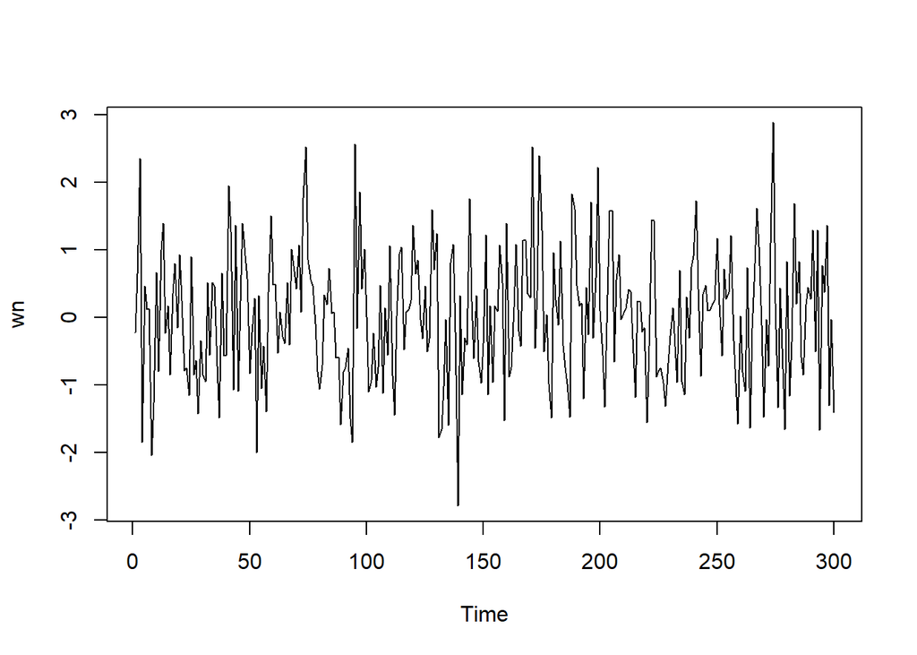

```r
set.seed(088)
wn <- rnorm(300)
ts.plot(wn)
```

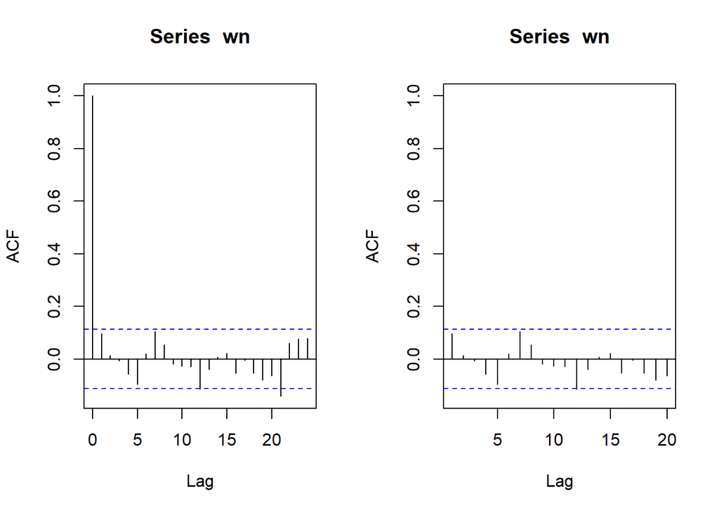

```r
par(mfrow = c(1, 2))
acf(wn)
acf(wn, xlim = c(1, 20))
```

```r
ma <- numeric(300)
ma[1] <- wn[1]
ma[2] <-wn[2]
```

```r
for(i in 3:300){
   ma[i] <- wn[i] + 0.4 * wn[i - 1] +0.6 * wn[i - 2]
}
ma
```

```
##   [1] -0.22625569  0.64656984  2.46893277 -0.51925351  1.12907852 -0.79971376
##   [7]  0.45847572 -1.91324660 -2.00402960 -1.06402450 -1.29505475  1.07638320
##  [13]  1.31112786  0.92606662  0.91513889 -0.92099723  0.11065554  0.42081676
##  [19]  0.37699979  1.33755988  0.53178989 -0.13476186 -0.90987137 -1.92748580
##  [25] -0.01042834 -1.18505823 -0.43550438 -2.18539381 -1.29082042 -1.83832931
##  [31] -1.49558957 -0.37443958 -0.92289441  0.59502994  0.33042592 -0.22396376
##  [37] -1.49018539 -0.37104997 -1.19722121 -0.40108780  1.38137347  1.71042712
##  [43]  0.60898229  1.69758293 -1.18301895  0.62789651  0.83793591  1.61875432
##  [49]  1.77084374 -0.05240392 -0.21110351 -0.30701279 -2.01904427 -0.31018744
##  [55] -2.12554107 -0.65948782 -2.20130435 -0.44433009  0.80970462  1.30790959
##  [61]  1.58807182 -0.04165096  0.16500144 -0.57446624 -0.44838402  0.18377697
##  [67] -0.43373928  1.14994326  0.84549578  1.30325049  1.64964876  0.75955571
##  [73]  2.44117341  3.27445806  2.92130002  2.41878625  1.21311437  0.44185159
##  [79] -0.54482501 -1.43653455 -1.61035748 -0.58870203 -0.10605135  0.99899855
##  [85]  0.45584230  0.53858140 -0.53561735 -0.78044471 -2.18612682 -1.79537094
```

[output cut: 35 more lines]

#Manual

```r
set.seed(088)
ma1 <- arima.sim(list(order=c(0,0,2), ma=c(0.4,0.6)), n=300)
ma1
```

```
## Time Series:
## Start = 1
## End = 300
## Frequency = 1
##   [1]  2.46893277 -0.51925351  1.12907852 -0.79971376  0.45847572 -1.91324660
##   [7] -2.00402960 -1.06402450 -1.29505475  1.07638320  1.31112786  0.92606662
##  [13]  0.91513889 -0.92099723  0.11065554  0.42081676  0.37699979  1.33755988
##  [19]  0.53178989 -0.13476186 -0.90987137 -1.92748580 -0.01042834 -1.18505823
##  [25] -0.43550438 -2.18539381 -1.29082042 -1.83832931 -1.49558957 -0.37443958
##  [31] -0.92289441  0.59502994  0.33042592 -0.22396376 -1.49018539 -0.37104997
##  [37] -1.19722121 -0.40108780  1.38137347  1.71042712  0.60898229  1.69758293
##  [43] -1.18301895  0.62789651  0.83793591  1.61875432  1.77084374 -0.05240392
##  [49] -0.21110351 -0.30701279 -2.01904427 -0.31018744 -2.12554107 -0.65948782
##  [55] -2.20130435 -0.44433009  0.80970462  1.30790959  1.58807182 -0.04165096
##  [61]  0.16500144 -0.57446624 -0.44838402  0.18377697 -0.43373928  1.14994326
```

[output cut: 39 more lines]

### Plot Time Series

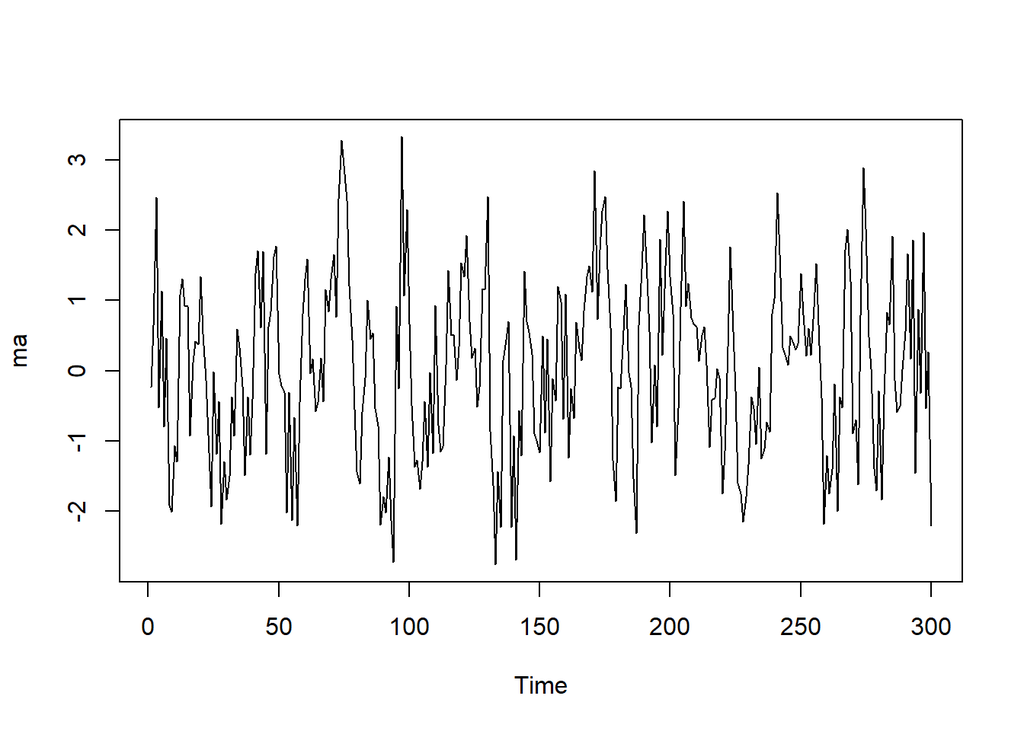

```r
ts.plot(ma)
```

Berdasarkan plot time series, terlihat bahwa data MA(2) yang dibangkitkan stasioner dalam rataan

### Plot ACF

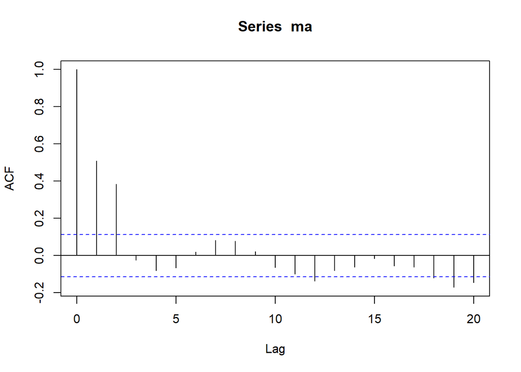

```r
acf(ma,lag.max = 20)
```

Berdasarkan plot AFC tersebut, terlihat bahwa plot ACF *cuts off* di lag pertama, kedua, dua belas dan sembilan belas. (autokorelasi dan stasioner)

### Plot PACF

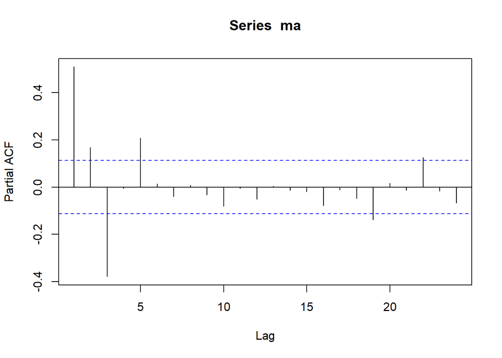

```r
pacf(ma)
```

Berdasarkan plot AFC tersebut, terlihat bahwa plot ACF *cuts off* di lag pertama, kedua, ketiga, kelima, sembilan belas dan dua puluh dua. (Terdapat autokolerasi dan stasioner)

### Plot EACF

```r
TSA::eacf(ma)
```

```
## AR/MA
##   0 1 2 3 4 5 6 7 8 9 10 11 12 13
## 0 x x o o o o o o o o o  x  o  o
## 1 x x x o o o o o o o o  o  o  o
## 2 x x x x o o o o o o o  o  o  o
## 3 o x x x x o o o o o o  o  o  o
## 4 o x x x o o o o o o o  o  o  o
## 5 o x o x o o o o o o o  o  o  o
## 6 x x o o x o o o o o o  o  o  o
## 7 x x o o o o o o o o o  o  o  o
```

Berdasarkan pola segitiga nol pada plot EACF, terlihat bahwa segitiga nol berada pada ordo AR(0) dan ordo MA(2)

### Scatterplot Antar Lag

#### Korelasi antara $Y_t$ dengan $Y_{t-1}$

```r
#Yt
yt_ma <- ma[-1]
yt_ma
```

```
##   [1]  0.64656984  2.46893277 -0.51925351  1.12907852 -0.79971376  0.45847572
##   [7] -1.91324660 -2.00402960 -1.06402450 -1.29505475  1.07638320  1.31112786
##  [13]  0.92606662  0.91513889 -0.92099723  0.11065554  0.42081676  0.37699979
##  [19]  1.33755988  0.53178989 -0.13476186 -0.90987137 -1.92748580 -0.01042834
##  [25] -1.18505823 -0.43550438 -2.18539381 -1.29082042 -1.83832931 -1.49558957
##  [31] -0.37443958 -0.92289441  0.59502994  0.33042592 -0.22396376 -1.49018539
##  [37] -0.37104997 -1.19722121 -0.40108780  1.38137347  1.71042712  0.60898229
##  [43]  1.69758293 -1.18301895  0.62789651  0.83793591  1.61875432  1.77084374
##  [49] -0.05240392 -0.21110351 -0.30701279 -2.01904427 -0.31018744 -2.12554107
##  [55] -0.65948782 -2.20130435 -0.44433009  0.80970462  1.30790959  1.58807182
##  [61] -0.04165096  0.16500144 -0.57446624 -0.44838402  0.18377697 -0.43373928
##  [67]  1.14994326  0.84549578  1.30325049  1.64964876  0.75955571  2.44117341
##  [73]  3.27445806  2.92130002  2.41878625  1.21311437  0.44185159 -0.54482501
##  [79] -1.43653455 -1.61035748 -0.58870203 -0.10605135  0.99899855  0.45584230
##  [85]  0.53858140 -0.53561735 -0.78044471 -2.18612682 -1.79537094 -2.01558058
```

[output cut: 35 more lines]

```r
#Yt-1
yt_1_ma <- ma[-300]
yt_1_ma
```

```
##   [1] -0.22625569  0.64656984  2.46893277 -0.51925351  1.12907852 -0.79971376
##   [7]  0.45847572 -1.91324660 -2.00402960 -1.06402450 -1.29505475  1.07638320
##  [13]  1.31112786  0.92606662  0.91513889 -0.92099723  0.11065554  0.42081676
##  [19]  0.37699979  1.33755988  0.53178989 -0.13476186 -0.90987137 -1.92748580
##  [25] -0.01042834 -1.18505823 -0.43550438 -2.18539381 -1.29082042 -1.83832931
##  [31] -1.49558957 -0.37443958 -0.92289441  0.59502994  0.33042592 -0.22396376
##  [37] -1.49018539 -0.37104997 -1.19722121 -0.40108780  1.38137347  1.71042712
##  [43]  0.60898229  1.69758293 -1.18301895  0.62789651  0.83793591  1.61875432
##  [49]  1.77084374 -0.05240392 -0.21110351 -0.30701279 -2.01904427 -0.31018744
##  [55] -2.12554107 -0.65948782 -2.20130435 -0.44433009  0.80970462  1.30790959
##  [61]  1.58807182 -0.04165096  0.16500144 -0.57446624 -0.44838402  0.18377697
##  [67] -0.43373928  1.14994326  0.84549578  1.30325049  1.64964876  0.75955571
##  [73]  2.44117341  3.27445806  2.92130002  2.41878625  1.21311437  0.44185159
##  [79] -0.54482501 -1.43653455 -1.61035748 -0.58870203 -0.10605135  0.99899855
##  [85]  0.45584230  0.53858140 -0.53561735 -0.78044471 -2.18612682 -1.79537094
```

[output cut: 35 more lines]

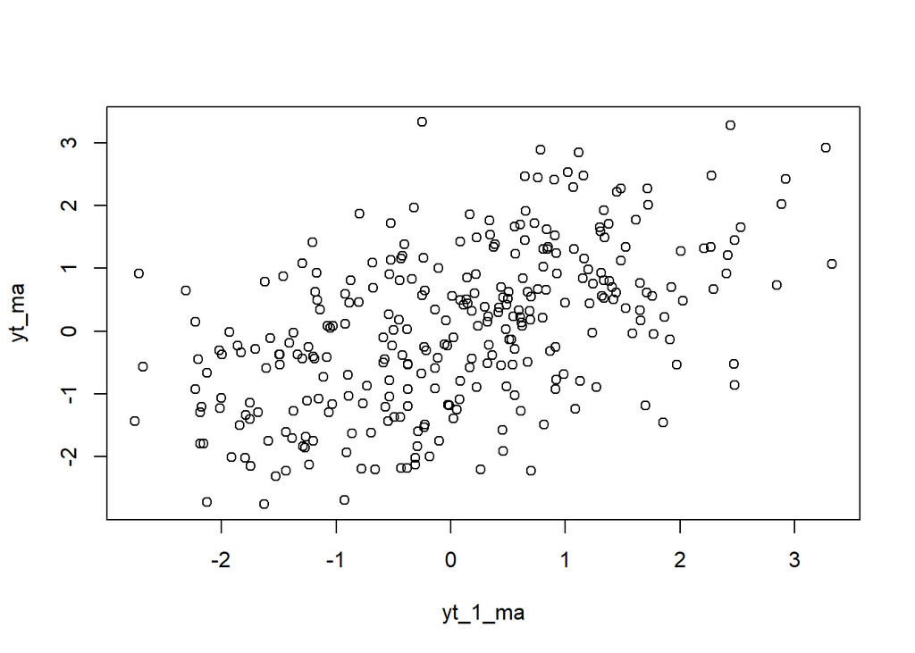

```r
plot(y=yt_ma,x=yt_1_ma)
```

```r
cor(yt_ma,yt_1_ma)
```

```
## [1] 0.5115399
```

#### Korelasi antara $Y_t$ dengan $Y_{t-2}$

```r
#Yt
yt_ma2 <- ma[-c(1,2)]
yt_ma2
```

```
##   [1]  2.46893277 -0.51925351  1.12907852 -0.79971376  0.45847572 -1.91324660
##   [7] -2.00402960 -1.06402450 -1.29505475  1.07638320  1.31112786  0.92606662
##  [13]  0.91513889 -0.92099723  0.11065554  0.42081676  0.37699979  1.33755988
##  [19]  0.53178989 -0.13476186 -0.90987137 -1.92748580 -0.01042834 -1.18505823
##  [25] -0.43550438 -2.18539381 -1.29082042 -1.83832931 -1.49558957 -0.37443958
##  [31] -0.92289441  0.59502994  0.33042592 -0.22396376 -1.49018539 -0.37104997
##  [37] -1.19722121 -0.40108780  1.38137347  1.71042712  0.60898229  1.69758293
##  [43] -1.18301895  0.62789651  0.83793591  1.61875432  1.77084374 -0.05240392
##  [49] -0.21110351 -0.30701279 -2.01904427 -0.31018744 -2.12554107 -0.65948782
##  [55] -2.20130435 -0.44433009  0.80970462  1.30790959  1.58807182 -0.04165096
##  [61]  0.16500144 -0.57446624 -0.44838402  0.18377697 -0.43373928  1.14994326
##  [67]  0.84549578  1.30325049  1.64964876  0.75955571  2.44117341  3.27445806
##  [73]  2.92130002  2.41878625  1.21311437  0.44185159 -0.54482501 -1.43653455
##  [79] -1.61035748 -0.58870203 -0.10605135  0.99899855  0.45584230  0.53858140
##  [85] -0.53561735 -0.78044471 -2.18612682 -1.79537094 -2.01558058 -1.23265217
```

[output cut: 35 more lines]

```r
#Yt-2
yt_2_ma <- ma[-c(299,300)]
yt_2_ma
```

```
##   [1] -0.22625569  0.64656984  2.46893277 -0.51925351  1.12907852 -0.79971376
##   [7]  0.45847572 -1.91324660 -2.00402960 -1.06402450 -1.29505475  1.07638320
##  [13]  1.31112786  0.92606662  0.91513889 -0.92099723  0.11065554  0.42081676
##  [19]  0.37699979  1.33755988  0.53178989 -0.13476186 -0.90987137 -1.92748580
##  [25] -0.01042834 -1.18505823 -0.43550438 -2.18539381 -1.29082042 -1.83832931
##  [31] -1.49558957 -0.37443958 -0.92289441  0.59502994  0.33042592 -0.22396376
##  [37] -1.49018539 -0.37104997 -1.19722121 -0.40108780  1.38137347  1.71042712
##  [43]  0.60898229  1.69758293 -1.18301895  0.62789651  0.83793591  1.61875432
##  [49]  1.77084374 -0.05240392 -0.21110351 -0.30701279 -2.01904427 -0.31018744
##  [55] -2.12554107 -0.65948782 -2.20130435 -0.44433009  0.80970462  1.30790959
##  [61]  1.58807182 -0.04165096  0.16500144 -0.57446624 -0.44838402  0.18377697
##  [67] -0.43373928  1.14994326  0.84549578  1.30325049  1.64964876  0.75955571
##  [73]  2.44117341  3.27445806  2.92130002  2.41878625  1.21311437  0.44185159
##  [79] -0.54482501 -1.43653455 -1.61035748 -0.58870203 -0.10605135  0.99899855
##  [85]  0.45584230  0.53858140 -0.53561735 -0.78044471 -2.18612682 -1.79537094
```

[output cut: 35 more lines]

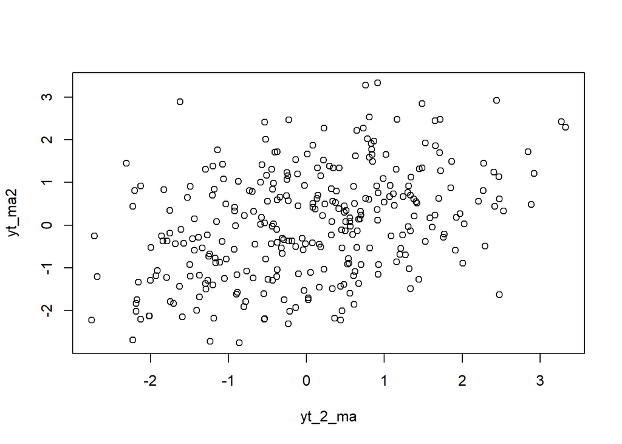

```r
plot(y=yt_ma2,x=yt_2_ma)
```

```r
cor(yt_ma2,yt_2_ma)
```

```
## [1] 0.386337
```

#### Korelasi antara $Y_t$ dengan $Y_{t-3}$

```r
#Yt
yt_ma3 <- ma[-c(1,2,3)]
yt_ma3
```

```
##   [1] -0.51925351  1.12907852 -0.79971376  0.45847572 -1.91324660 -2.00402960
##   [7] -1.06402450 -1.29505475  1.07638320  1.31112786  0.92606662  0.91513889
##  [13] -0.92099723  0.11065554  0.42081676  0.37699979  1.33755988  0.53178989
##  [19] -0.13476186 -0.90987137 -1.92748580 -0.01042834 -1.18505823 -0.43550438
##  [25] -2.18539381 -1.29082042 -1.83832931 -1.49558957 -0.37443958 -0.92289441
##  [31]  0.59502994  0.33042592 -0.22396376 -1.49018539 -0.37104997 -1.19722121
##  [37] -0.40108780  1.38137347  1.71042712  0.60898229  1.69758293 -1.18301895
##  [43]  0.62789651  0.83793591  1.61875432  1.77084374 -0.05240392 -0.21110351
##  [49] -0.30701279 -2.01904427 -0.31018744 -2.12554107 -0.65948782 -2.20130435
##  [55] -0.44433009  0.80970462  1.30790959  1.58807182 -0.04165096  0.16500144
##  [61] -0.57446624 -0.44838402  0.18377697 -0.43373928  1.14994326  0.84549578
##  [67]  1.30325049  1.64964876  0.75955571  2.44117341  3.27445806  2.92130002
##  [73]  2.41878625  1.21311437  0.44185159 -0.54482501 -1.43653455 -1.61035748
##  [79] -0.58870203 -0.10605135  0.99899855  0.45584230  0.53858140 -0.53561735
##  [85] -0.78044471 -2.18612682 -1.79537094 -2.01558058 -1.23265217 -2.12569780
```

[output cut: 35 more lines]

```r
#Yt-3
yt_3_ma <- ma[-c(298,299,300)]
yt_3_ma
```

```
##   [1] -0.22625569  0.64656984  2.46893277 -0.51925351  1.12907852 -0.79971376
##   [7]  0.45847572 -1.91324660 -2.00402960 -1.06402450 -1.29505475  1.07638320
##  [13]  1.31112786  0.92606662  0.91513889 -0.92099723  0.11065554  0.42081676
##  [19]  0.37699979  1.33755988  0.53178989 -0.13476186 -0.90987137 -1.92748580
##  [25] -0.01042834 -1.18505823 -0.43550438 -2.18539381 -1.29082042 -1.83832931
##  [31] -1.49558957 -0.37443958 -0.92289441  0.59502994  0.33042592 -0.22396376
##  [37] -1.49018539 -0.37104997 -1.19722121 -0.40108780  1.38137347  1.71042712
##  [43]  0.60898229  1.69758293 -1.18301895  0.62789651  0.83793591  1.61875432
##  [49]  1.77084374 -0.05240392 -0.21110351 -0.30701279 -2.01904427 -0.31018744
##  [55] -2.12554107 -0.65948782 -2.20130435 -0.44433009  0.80970462  1.30790959
##  [61]  1.58807182 -0.04165096  0.16500144 -0.57446624 -0.44838402  0.18377697
##  [67] -0.43373928  1.14994326  0.84549578  1.30325049  1.64964876  0.75955571
##  [73]  2.44117341  3.27445806  2.92130002  2.41878625  1.21311437  0.44185159
##  [79] -0.54482501 -1.43653455 -1.61035748 -0.58870203 -0.10605135  0.99899855
##  [85]  0.45584230  0.53858140 -0.53561735 -0.78044471 -2.18612682 -1.79537094
```

[output cut: 35 more lines]

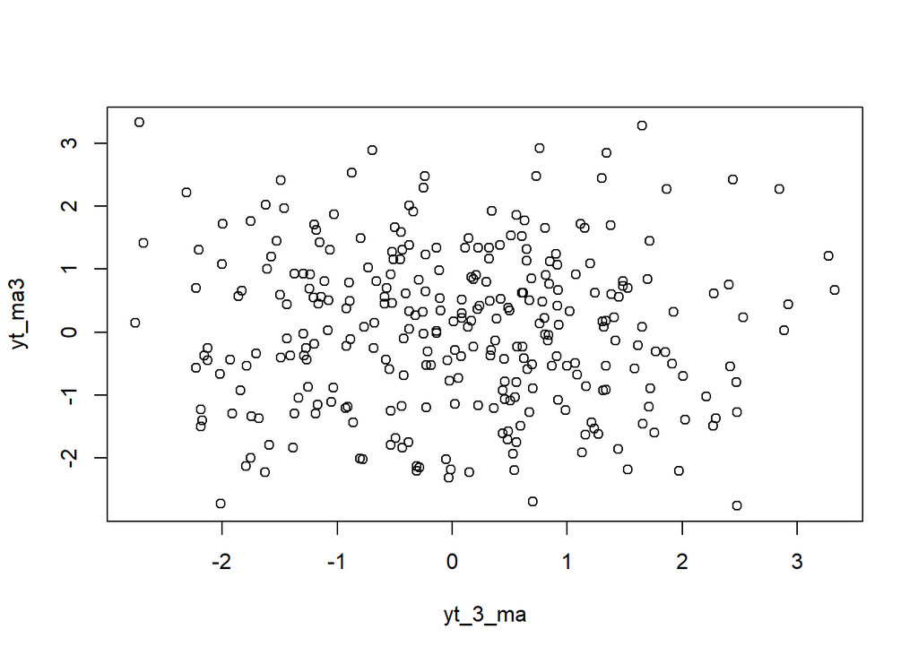

```r
plot(y=yt_ma3,x=yt_3_ma)
```

```r
cor(yt_ma3,yt_3_ma)
```

```
## [1] -0.02398495
```

## Pembangkitan Proses AR

```r
set.seed(088)
```

```r
n<-length(wn)
n
```

```
## [1] 300
```

```r
ar <- c(1:n)
for (i in 3:n) {ar[i]<-wn[i]+0.3*ar[i-1]+0.7*ar[i-2]}
ar
```

```
##   [1]  1.000000000  2.000000000  3.646058252  0.648198757  3.206391459
##   [6]  1.539437618  2.839453972 -0.111332177  0.686609210  0.795534132
##  [11] -0.082196265  1.528701058  1.794496147  1.379245293  1.840683565
##  [16]  0.665891050  1.837158040  1.809594451  1.679612092  2.692476385
##  [21]  2.236076733  1.766626507  1.349379076  0.485669498  1.989668528
##  [26]  0.085519714  0.783817907 -1.125732554 -0.130807374 -1.676435216
##  [31] -1.545357126 -1.121698684 -1.976802406 -0.869030594 -1.182598932
##  [36] -1.677333148 -2.812634921 -1.367788129 -2.947486879 -2.405544486
##  [41] -0.837008402 -0.665406802 -1.853113832  0.341152267 -2.282449879
##  [46] -0.200708222 -0.265510012  0.694506516  0.592026152 -0.165247164
##  [51]  0.143625751  0.206295025 -1.835438815 -0.084594617 -2.365659624
##  [56] -1.199190621 -3.411628233 -1.490722371 -1.336986084 -0.959359770
##  [61] -0.728745288 -1.420952573 -0.856066919 -1.539623054 -1.442467640
##  [66] -1.001284197 -1.718728455 -0.208643213 -0.578187296  0.104013259
##  [71]  0.694204397  0.359421881  2.362963622  3.480254102  3.550026515
```

[output cut: 45 more lines]

Selain menggunakan cara di atas, pembangkitan proses AR dapat dilakukan dengan fungsi `arima.sim()` sebagai berikut.

```r
ar1 <- arima.sim(list(order=c(2,0,0), ar=c(0.5,0.2)), n=300)
ar1
```

```
## Time Series:
## Start = 1
## End = 300
## Frequency = 1
##   [1] -1.124259366 -1.188117489 -2.239652343 -1.699209812 -2.146715590
##   [6] -2.364061157 -1.095960591 -1.579335340 -0.499660582 -0.103825429
##  [11] -0.866076883 -1.935419251 -0.490789452 -1.200784572 -1.262396909
##  [16]  1.076540390  1.555367673 -0.074593996  1.636647715 -0.284210818
##  [21]  0.430444289  1.550797350  1.776142808  1.767762080  0.410100031
##  [26]  0.337384025  0.529592333 -1.665592377 -0.405247211 -1.591216150
##  [31] -1.306934019 -2.367619550 -1.072997045  0.488347958  0.514816285
##  [36]  0.850030636 -0.002798572  0.248947396 -0.164222194 -0.413655499
##  [41]  0.269520044 -0.356586925  0.883484808  1.057940605  1.129186961
##  [46]  1.843913128  1.226145237  2.751049224  4.140523358  3.472347273
##  [51]  3.130452441  2.735214940  1.905637361  0.704949341 -0.332131117
```

[output cut: 49 more lines]

### Plot Time Series

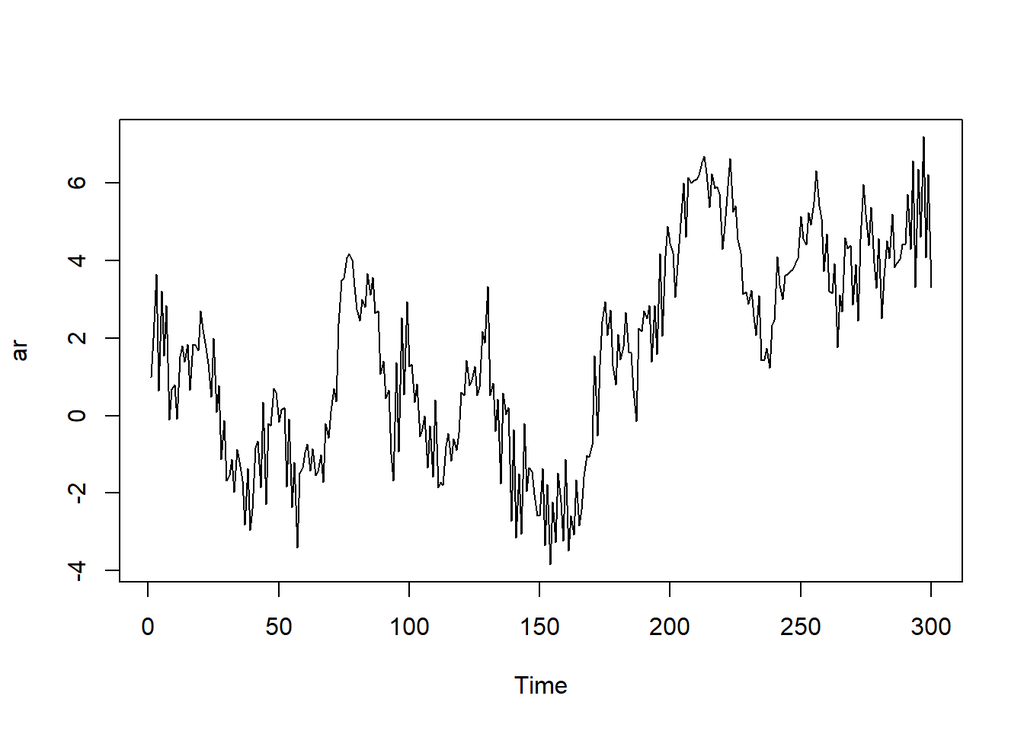

```r
ts.plot(ar)
```

Berdasarkan plot time series tersebut terlihat bahwa data cenderung tidak stasioner pada rataan

### Plot ACF

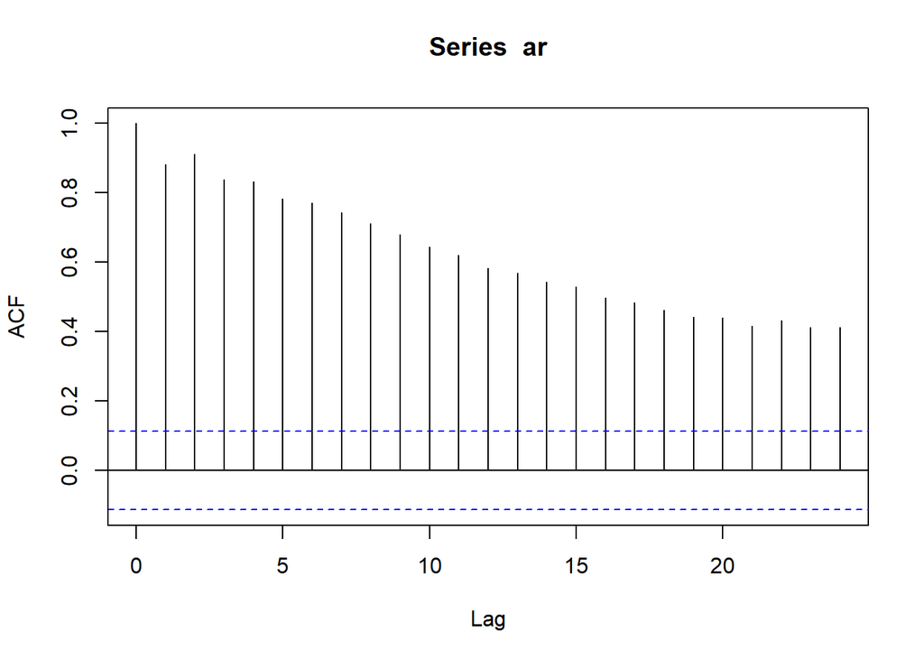

```r
acf(ar)
```

Berdasarkan plot ACF tersebut terlihat bahwa plot ACF cenderung *tails off lambat* menandakan tidak stasioner dan memiliki autokolerasi

### Plot PACF

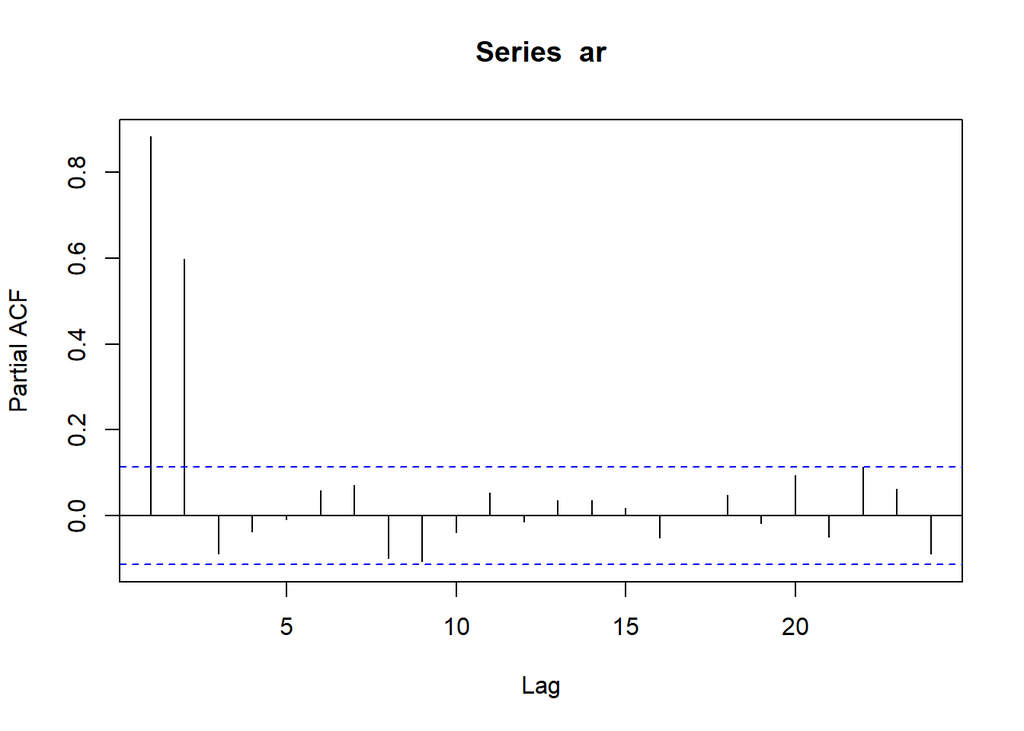

```r
pacf(ar)
```

Berdasarkan plot PACF tersebut, terlihat bahwa plot PACF *cuts off* pada lag pertama dan kedua

### Plot EACF

```r
TSA::eacf(ar)
```

```
## AR/MA
##   0 1 2 3 4 5 6 7 8 9 10 11 12 13
## 0 x x x x x x x x x x x  x  x  x
## 1 x x x x x o o o o o o  o  o  o
## 2 x o o o o o o o o o o  o  o  o
## 3 x o o o o o o o o o o  o  o  o
## 4 x o o o o o o x o o o  o  o  o
## 5 o x o o o o o o o o o  o  o  o
## 6 x x x o o o o o o o o  o  o  o
## 7 x x x x x o o x o o o  o  o  o
```

Berdasarkan pola segitiga nol pada plot EACF, terlihat bahwa segitiga nol berada pada ordo AR(2) dan ordo MA(1)

### Scatterplot Antar Lag

#### Korelasi antara $Y_t$ dengan $Y_{t-1}$

```r
#Yt
yt_ar <- ar[-1]
yt_ar
```

```
##   [1]  2.000000000  3.646058252  0.648198757  3.206391459  1.539437618
##   [6]  2.839453972 -0.111332177  0.686609210  0.795534132 -0.082196265
##  [11]  1.528701058  1.794496147  1.379245293  1.840683565  0.665891050
##  [16]  1.837158040  1.809594451  1.679612092  2.692476385  2.236076733
##  [21]  1.766626507  1.349379076  0.485669498  1.989668528  0.085519714
##  [26]  0.783817907 -1.125732554 -0.130807374 -1.676435216 -1.545357126
##  [31] -1.121698684 -1.976802406 -0.869030594 -1.182598932 -1.677333148
##  [36] -2.812634921 -1.367788129 -2.947486879 -2.405544486 -0.837008402
##  [41] -0.665406802 -1.853113832  0.341152267 -2.282449879 -0.200708222
##  [46] -0.265510012  0.694506516  0.592026152 -0.165247164  0.143625751
##  [51]  0.206295025 -1.835438815 -0.084594617 -2.365659624 -1.199190621
##  [56] -3.411628233 -1.490722371 -1.336986084 -0.959359770 -0.728745288
##  [61] -1.420952573 -0.856066919 -1.539623054 -1.442467640 -1.001284197
##  [66] -1.718728455 -0.208643213 -0.578187296  0.104013259  0.694204397
##  [71]  0.359421881  2.362963622  3.480254102  3.550026515  4.067359959
```

[output cut: 45 more lines]

```r
#Yt-1
yt_1_ar <- ar[-300]
yt_1_ar
```

```
##   [1]  1.000000000  2.000000000  3.646058252  0.648198757  3.206391459
##   [6]  1.539437618  2.839453972 -0.111332177  0.686609210  0.795534132
##  [11] -0.082196265  1.528701058  1.794496147  1.379245293  1.840683565
##  [16]  0.665891050  1.837158040  1.809594451  1.679612092  2.692476385
##  [21]  2.236076733  1.766626507  1.349379076  0.485669498  1.989668528
##  [26]  0.085519714  0.783817907 -1.125732554 -0.130807374 -1.676435216
##  [31] -1.545357126 -1.121698684 -1.976802406 -0.869030594 -1.182598932
##  [36] -1.677333148 -2.812634921 -1.367788129 -2.947486879 -2.405544486
##  [41] -0.837008402 -0.665406802 -1.853113832  0.341152267 -2.282449879
##  [46] -0.200708222 -0.265510012  0.694506516  0.592026152 -0.165247164
##  [51]  0.143625751  0.206295025 -1.835438815 -0.084594617 -2.365659624
##  [56] -1.199190621 -3.411628233 -1.490722371 -1.336986084 -0.959359770
##  [61] -0.728745288 -1.420952573 -0.856066919 -1.539623054 -1.442467640
##  [66] -1.001284197 -1.718728455 -0.208643213 -0.578187296  0.104013259
##  [71]  0.694204397  0.359421881  2.362963622  3.480254102  3.550026515
```

[output cut: 45 more lines]

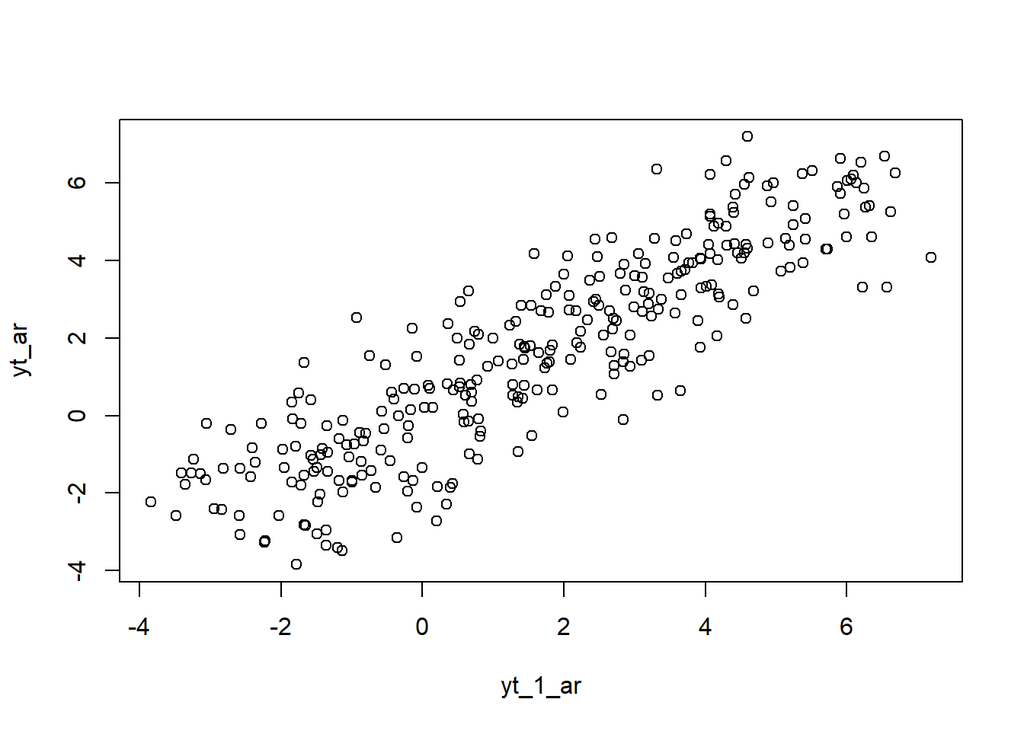

```r
plot(y=yt_ar,x=yt_1_ar)
```

Berdasarkan scatterplot tersebut, terlihat bahwa terdapat hubungan positif antara $Y_t$ dengan $Y_{t-1}$. Hal ini sesuai dengan teori yang ada

```r
cor(yt_ar,yt_1_ar)
```

```
## [1] 0.8829721
```

#### Korelasi antara $Y_t$ dengan $Y_{t-2}$

```r
#Yt
yt_ar2 <- ar[-c(1,2)]
yt_ar2
```

```
##   [1]  3.646058252  0.648198757  3.206391459  1.539437618  2.839453972
##   [6] -0.111332177  0.686609210  0.795534132 -0.082196265  1.528701058
##  [11]  1.794496147  1.379245293  1.840683565  0.665891050  1.837158040
##  [16]  1.809594451  1.679612092  2.692476385  2.236076733  1.766626507
##  [21]  1.349379076  0.485669498  1.989668528  0.085519714  0.783817907
##  [26] -1.125732554 -0.130807374 -1.676435216 -1.545357126 -1.121698684
##  [31] -1.976802406 -0.869030594 -1.182598932 -1.677333148 -2.812634921
##  [36] -1.367788129 -2.947486879 -2.405544486 -0.837008402 -0.665406802
##  [41] -1.853113832  0.341152267 -2.282449879 -0.200708222 -0.265510012
##  [46]  0.694506516  0.592026152 -0.165247164  0.143625751  0.206295025
##  [51] -1.835438815 -0.084594617 -2.365659624 -1.199190621 -3.411628233
##  [56] -1.490722371 -1.336986084 -0.959359770 -0.728745288 -1.420952573
##  [61] -0.856066919 -1.539623054 -1.442467640 -1.001284197 -1.718728455
##  [66] -0.208643213 -0.578187296  0.104013259  0.694204397  0.359421881
##  [71]  2.362963622  3.480254102  3.550026515  4.067359959  4.180745813
```

[output cut: 45 more lines]

```r
#Yt-2
yt_2_ar <- ar[-c(299,300)]
yt_2_ar
```

```
##   [1]  1.000000000  2.000000000  3.646058252  0.648198757  3.206391459
##   [6]  1.539437618  2.839453972 -0.111332177  0.686609210  0.795534132
##  [11] -0.082196265  1.528701058  1.794496147  1.379245293  1.840683565
##  [16]  0.665891050  1.837158040  1.809594451  1.679612092  2.692476385
##  [21]  2.236076733  1.766626507  1.349379076  0.485669498  1.989668528
##  [26]  0.085519714  0.783817907 -1.125732554 -0.130807374 -1.676435216
##  [31] -1.545357126 -1.121698684 -1.976802406 -0.869030594 -1.182598932
##  [36] -1.677333148 -2.812634921 -1.367788129 -2.947486879 -2.405544486
##  [41] -0.837008402 -0.665406802 -1.853113832  0.341152267 -2.282449879
##  [46] -0.200708222 -0.265510012  0.694506516  0.592026152 -0.165247164
##  [51]  0.143625751  0.206295025 -1.835438815 -0.084594617 -2.365659624
##  [56] -1.199190621 -3.411628233 -1.490722371 -1.336986084 -0.959359770
##  [61] -0.728745288 -1.420952573 -0.856066919 -1.539623054 -1.442467640
##  [66] -1.001284197 -1.718728455 -0.208643213 -0.578187296  0.104013259
##  [71]  0.694204397  0.359421881  2.362963622  3.480254102  3.550026515
```

[output cut: 45 more lines]

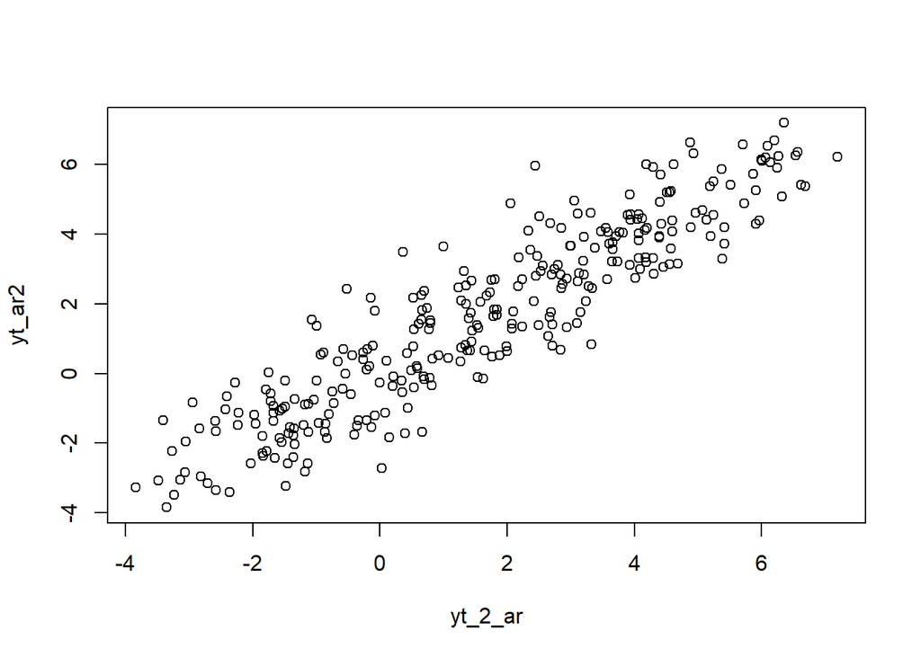

```r
plot(y=yt_ar2,x=yt_2_ar)
```

Berdasarkan scatterplot tersebut, terlihat bahwa terdapat hubungan positif antara $Y_t$ dengan $Y_{t-2}$. Hal ini sesuai dengan teori yang ada

```r
cor(yt_ar2,yt_2_ar)
```

```
## [1] 0.9164209
```

#### Korelasi antara $Y_t$ dengan $Y_{t-3}$

```r
#Yt
yt_ar3 <- ar[-c(1,2,3)]
yt_ar3
```

```
##   [1]  0.648198757  3.206391459  1.539437618  2.839453972 -0.111332177
##   [6]  0.686609210  0.795534132 -0.082196265  1.528701058  1.794496147
##  [11]  1.379245293  1.840683565  0.665891050  1.837158040  1.809594451
##  [16]  1.679612092  2.692476385  2.236076733  1.766626507  1.349379076
##  [21]  0.485669498  1.989668528  0.085519714  0.783817907 -1.125732554
##  [26] -0.130807374 -1.676435216 -1.545357126 -1.121698684 -1.976802406
##  [31] -0.869030594 -1.182598932 -1.677333148 -2.812634921 -1.367788129
##  [36] -2.947486879 -2.405544486 -0.837008402 -0.665406802 -1.853113832
##  [41]  0.341152267 -2.282449879 -0.200708222 -0.265510012  0.694506516
##  [46]  0.592026152 -0.165247164  0.143625751  0.206295025 -1.835438815
##  [51] -0.084594617 -2.365659624 -1.199190621 -3.411628233 -1.490722371
##  [56] -1.336986084 -0.959359770 -0.728745288 -1.420952573 -0.856066919
##  [61] -1.539623054 -1.442467640 -1.001284197 -1.718728455 -0.208643213
##  [66] -0.578187296  0.104013259  0.694204397  0.359421881  2.362963622
##  [71]  3.480254102  3.550026515  4.067359959  4.180745813  4.013315118
```

[output cut: 45 more lines]

```r
#Yt-3
yt_3_ar <- ar[-c(298,299,300)]
yt_3_ar
```

```
##   [1]  1.000000000  2.000000000  3.646058252  0.648198757  3.206391459
##   [6]  1.539437618  2.839453972 -0.111332177  0.686609210  0.795534132
##  [11] -0.082196265  1.528701058  1.794496147  1.379245293  1.840683565
##  [16]  0.665891050  1.837158040  1.809594451  1.679612092  2.692476385
##  [21]  2.236076733  1.766626507  1.349379076  0.485669498  1.989668528
##  [26]  0.085519714  0.783817907 -1.125732554 -0.130807374 -1.676435216
##  [31] -1.545357126 -1.121698684 -1.976802406 -0.869030594 -1.182598932
##  [36] -1.677333148 -2.812634921 -1.367788129 -2.947486879 -2.405544486
##  [41] -0.837008402 -0.665406802 -1.853113832  0.341152267 -2.282449879
##  [46] -0.200708222 -0.265510012  0.694506516  0.592026152 -0.165247164
##  [51]  0.143625751  0.206295025 -1.835438815 -0.084594617 -2.365659624
##  [56] -1.199190621 -3.411628233 -1.490722371 -1.336986084 -0.959359770
##  [61] -0.728745288 -1.420952573 -0.856066919 -1.539623054 -1.442467640
##  [66] -1.001284197 -1.718728455 -0.208643213 -0.578187296  0.104013259
##  [71]  0.694204397  0.359421881  2.362963622  3.480254102  3.550026515
```

[output cut: 45 more lines]

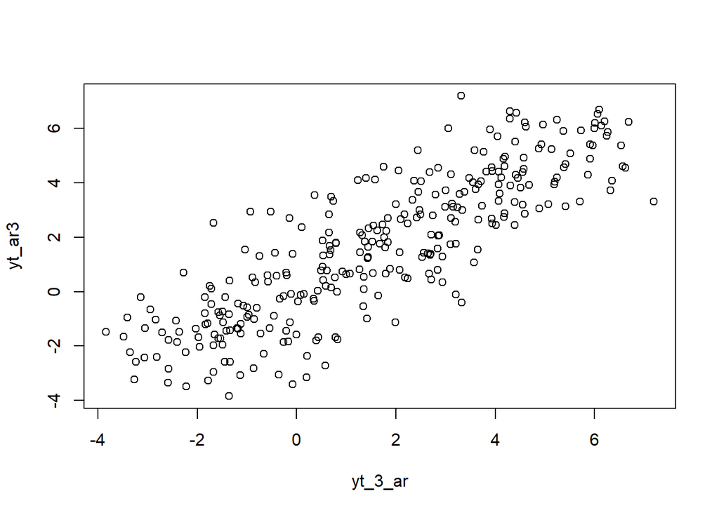

```r
plot(y=yt_ar3,x=yt_3_ar)
```

```r
cor(yt_ar3,yt_3_ar)
```

```
## [1] 0.8451576
```

## Fungsi pembangkitan ARMA

```r
set.seed(088)
n = length(wn)
phi1 = 0.4
phi2 = 0.6
theta1 = 0.5
theta2 = 0.2

y.arma=c(1:n)
for (i in 3:n){y.arma[i] = phi1*y.arma[i-1] + theta1*wn[i-1]+wn[i]+phi2*y.arma[i-2] + theta2*wn[i-2] }
y.arma
```

```
##   [1]  1.0000000  2.0000000  4.0240920  2.2663612  3.3270930  2.6751568
##   [7]  3.3532959  0.9969683  0.1493983  0.2834648 -0.5182379  0.6920251
##  [13]  1.6972370  1.7609244  2.0575621  1.0673362  1.6186436  2.0842814
##  [19]  2.1215660  3.1048981  3.1985871  2.6641218  1.8949945  0.6699708
##  [25]  1.5773234  0.4001069  0.2260366 -1.5778358 -1.6745646 -2.9207360
##  [31] -3.6168367 -3.3290299 -3.9927225 -3.2614965 -3.0954691 -3.5765418
##  [37] -5.0342556 -4.3931460 -5.3173731 -5.4808095 -3.8304365 -2.6899049
##  [43] -3.4174422 -1.8979262 -3.4293332 -2.5365026 -1.7746967 -0.5718722
##  [49]  0.0117754 -0.6997261 -0.7946421 -0.7352233 -2.6735435 -2.1320775
##  [55] -3.7511890 -3.6734095 -5.5422196 -4.8327440 -3.8531410 -3.1320360
##  [61] -2.5274512 -3.0764544 -2.8331099 -3.3332379 -3.5424950 -3.1560427
##  [67] -3.6182006 -2.4355011 -2.0353912 -1.3066048 -0.3268821 -0.2177947
##  [73]  1.7386687  3.9848276  5.1027317  5.9280552  6.3618426  6.3645040
##  [79]  5.6190684  4.5855282  3.8066864  4.0408711  4.1105141  4.9527715
##  [85]  4.9018388  5.1865061  4.4662514  4.0251842  2.2853125  1.6104490
```

[output cut: 35 more lines]

Pembangkitan ARMA(p,q) juga dapat dilakukan dengan fungsi `arima.sim` sebagai berikut.

```r
arma22 <-arima.sim(list(order=c(2,0,2), ar=c(0.5,0.2), ma = c(0.4,0.6)), n=300)
arma22
```

```
## Time Series:
## Start = 1
## End = 300
## Frequency = 1
##   [1] -3.38970122 -3.30812898 -4.17033404 -4.24238239 -3.32969759 -3.43621968
##   [7] -1.78901941 -1.25132772 -1.20743150 -2.34416668 -1.78461961 -2.55836435
##  [13] -2.03719390 -0.14889635  1.22854017  1.19347310  2.54002752  0.32568943
##  [19]  1.29874673  1.55244715  2.65472724  3.40869679  2.18288992  1.56208081
##  [25]  0.91060560 -1.25132531 -0.75372897 -2.75267062 -2.18656893 -3.84512294
##  [31] -2.80420535 -1.36142264  0.06635720  1.34896589  0.64610343  0.75784633
##  [37] -0.06632239 -0.32997595  0.00552452 -0.49697221  0.90256206  1.19738237
##  [43]  2.08245409  2.93035227  2.64122266  4.34785519  5.97663019  6.77918615
##  [49]  7.00370536  6.07080428  4.87799480  3.10833325  1.09323104 -0.44207532
##  [55] -0.59109348 -0.49001315  0.63577328  0.67572631  1.00359921  0.10132752
##  [61] -0.52906110 -2.43039187 -3.11637910 -4.05984851 -3.88585224 -4.88059362
```

[output cut: 39 more lines]

### Plot Time Series

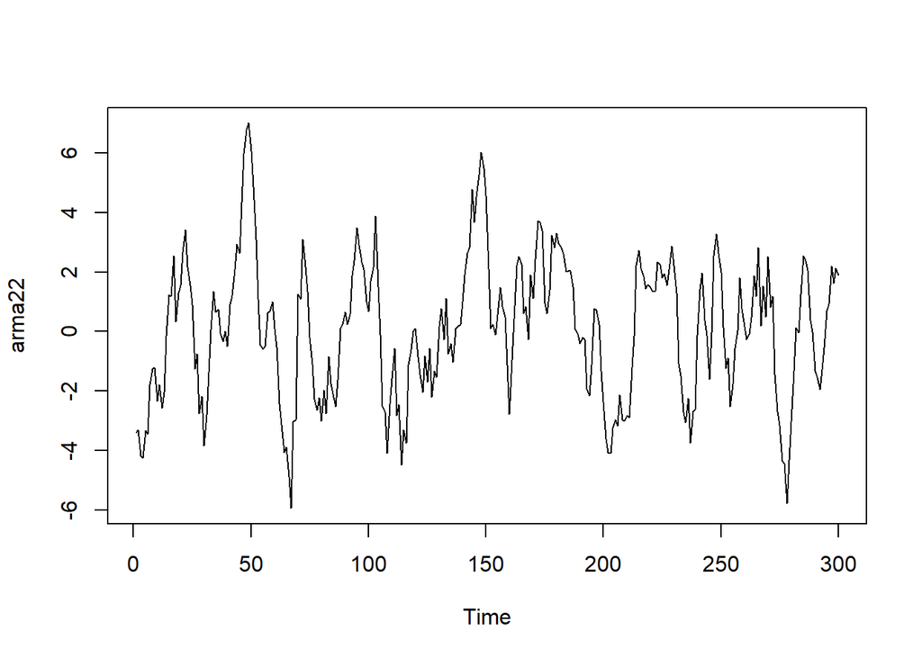

```r
ts.plot(arma22)
```

Berdasarkan plot time series tersebut, terlihat bahwa model ARMA(2,2) cenderung stasioner dalam rataan

### Plot ACF

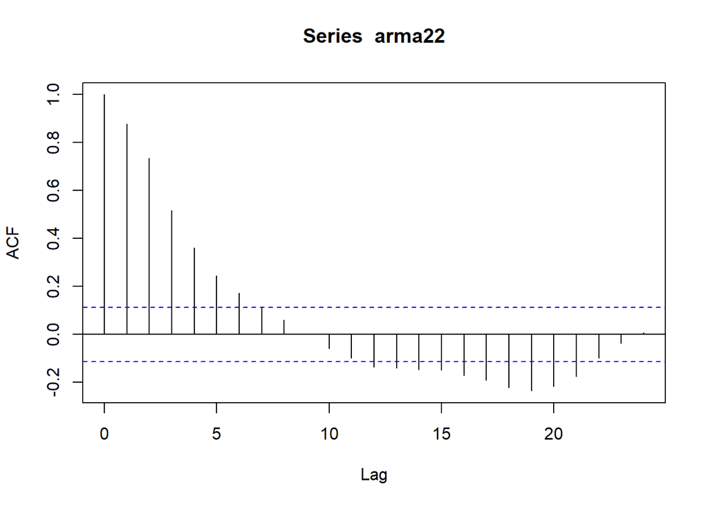

```r
acf(arma22)
```

Berdasarkan plot ACF tersebut, terlihat bahwa model ARMA(2,2) hasil simulasi memiliki plot ACF yang *tails off* dan stasioner

### Plot PACF

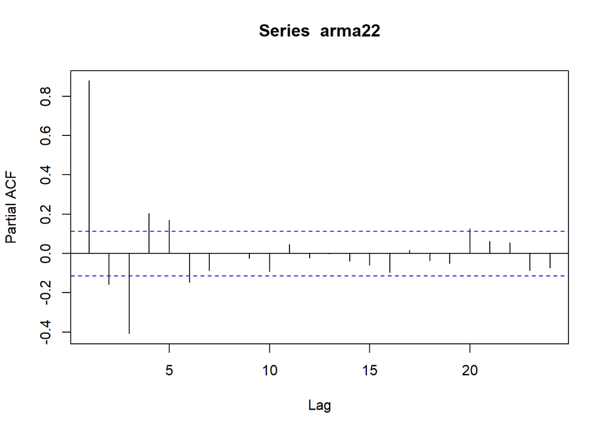

```r
pacf(arma22)
```

### Plot EACF

```r
TSA::eacf(arma22)
```

```
## AR/MA
##   0 1 2 3 4 5 6 7 8 9 10 11 12 13
## 0 x x x x x x o o o o o  x  x  x
## 1 x x o o o o o o o o o  x  o  o
## 2 x x o o o o o o o o o  x  o  o
## 3 x x x o o o o o o o o  x  o  o
## 4 x x x o o o o o o o o  o  o  o
## 5 x x x x o o o o o o o  o  o  o
## 6 x x x x x o o o o o o  o  o  o
## 7 o x o o x o x o o o o  o  o  o
```

Berdasarkan pola segitiga nol pada plot EACF, terlihat bahwa segitiga nol berada pada ordo AR(1) dan ordo MA(2)

### Scatterplot Antar Lag

#### Korelasi antara $Y_t$ dengan $Y_{t-1}$

```r
#Yt
yt_arma <- arma22[-1]
yt_arma
```

```
##   [1] -3.30812898 -4.17033404 -4.24238239 -3.32969759 -3.43621968 -1.78901941
##   [7] -1.25132772 -1.20743150 -2.34416668 -1.78461961 -2.55836435 -2.03719390
##  [13] -0.14889635  1.22854017  1.19347310  2.54002752  0.32568943  1.29874673
##  [19]  1.55244715  2.65472724  3.40869679  2.18288992  1.56208081  0.91060560
##  [25] -1.25132531 -0.75372897 -2.75267062 -2.18656893 -3.84512294 -2.80420535
##  [31] -1.36142264  0.06635720  1.34896589  0.64610343  0.75784633 -0.06632239
##  [37] -0.32997595  0.00552452 -0.49697221  0.90256206  1.19738237  2.08245409
##  [43]  2.93035227  2.64122266  4.34785519  5.97663019  6.77918615  7.00370536
##  [49]  6.07080428  4.87799480  3.10833325  1.09323104 -0.44207532 -0.59109348
##  [55] -0.49001315  0.63577328  0.67572631  1.00359921  0.10132752 -0.52906110
##  [61] -2.43039187 -3.11637910 -4.05984851 -3.88585224 -4.88059362 -5.93680556
##  [67] -3.02681564 -2.95115843  1.24516989  1.10316963  3.09650380  2.44070489
##  [73]  1.34952562 -0.20602668 -1.09847618 -2.27237385 -2.64728518 -2.21643506
##  [79] -3.01018840 -1.97131180 -2.75580724 -0.84866299 -1.74383782 -2.19571982
##  [85] -2.52034040 -1.61849899  0.10953163  0.23049227  0.64807339  0.23373869
```

[output cut: 35 more lines]

```r
#Yt-1
yt_1_arma <- arma22[-300]
yt_1_arma
```

```
##   [1] -3.38970122 -3.30812898 -4.17033404 -4.24238239 -3.32969759 -3.43621968
##   [7] -1.78901941 -1.25132772 -1.20743150 -2.34416668 -1.78461961 -2.55836435
##  [13] -2.03719390 -0.14889635  1.22854017  1.19347310  2.54002752  0.32568943
##  [19]  1.29874673  1.55244715  2.65472724  3.40869679  2.18288992  1.56208081
##  [25]  0.91060560 -1.25132531 -0.75372897 -2.75267062 -2.18656893 -3.84512294
##  [31] -2.80420535 -1.36142264  0.06635720  1.34896589  0.64610343  0.75784633
##  [37] -0.06632239 -0.32997595  0.00552452 -0.49697221  0.90256206  1.19738237
##  [43]  2.08245409  2.93035227  2.64122266  4.34785519  5.97663019  6.77918615
##  [49]  7.00370536  6.07080428  4.87799480  3.10833325  1.09323104 -0.44207532
##  [55] -0.59109348 -0.49001315  0.63577328  0.67572631  1.00359921  0.10132752
##  [61] -0.52906110 -2.43039187 -3.11637910 -4.05984851 -3.88585224 -4.88059362
##  [67] -5.93680556 -3.02681564 -2.95115843  1.24516989  1.10316963  3.09650380
##  [73]  2.44070489  1.34952562 -0.20602668 -1.09847618 -2.27237385 -2.64728518
##  [79] -2.21643506 -3.01018840 -1.97131180 -2.75580724 -0.84866299 -1.74383782
##  [85] -2.19571982 -2.52034040 -1.61849899  0.10953163  0.23049227  0.64807339
```

[output cut: 35 more lines]

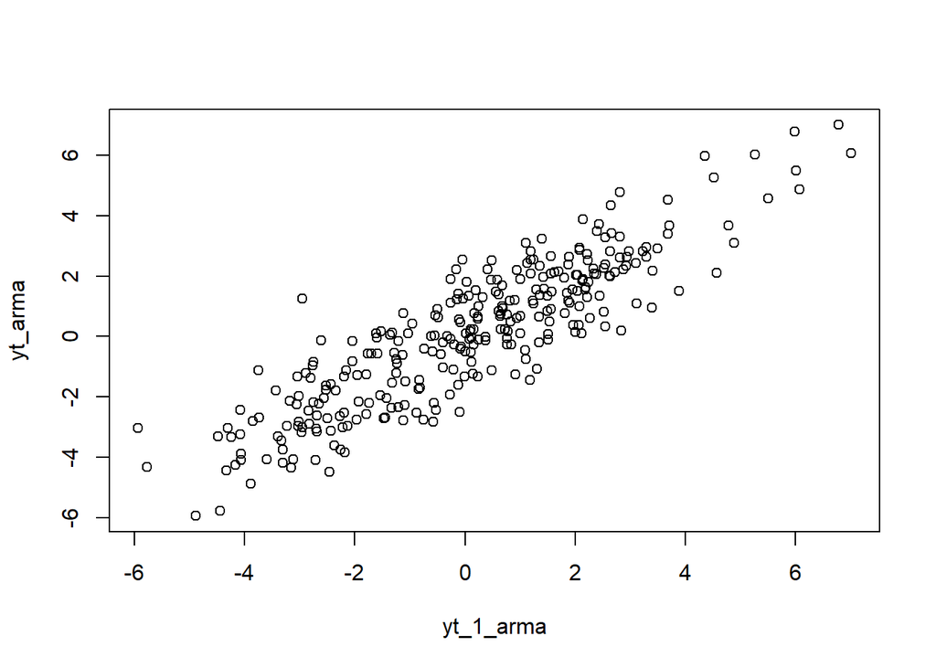

```r
plot(y=yt_arma,x=yt_1_arma)
```

```r
cor(yt_arma,yt_1_arma)
```

```
## [1] 0.882252
```

#### Korelasi antara $Y_t$ dengan $Y_{t-2}$

```r
#Yt
yt_arma2 <- arma22[-c(1,2)]
yt_arma2
```

```
##   [1] -4.17033404 -4.24238239 -3.32969759 -3.43621968 -1.78901941 -1.25132772
##   [7] -1.20743150 -2.34416668 -1.78461961 -2.55836435 -2.03719390 -0.14889635
##  [13]  1.22854017  1.19347310  2.54002752  0.32568943  1.29874673  1.55244715
##  [19]  2.65472724  3.40869679  2.18288992  1.56208081  0.91060560 -1.25132531
##  [25] -0.75372897 -2.75267062 -2.18656893 -3.84512294 -2.80420535 -1.36142264
##  [31]  0.06635720  1.34896589  0.64610343  0.75784633 -0.06632239 -0.32997595
##  [37]  0.00552452 -0.49697221  0.90256206  1.19738237  2.08245409  2.93035227
##  [43]  2.64122266  4.34785519  5.97663019  6.77918615  7.00370536  6.07080428
##  [49]  4.87799480  3.10833325  1.09323104 -0.44207532 -0.59109348 -0.49001315
##  [55]  0.63577328  0.67572631  1.00359921  0.10132752 -0.52906110 -2.43039187
##  [61] -3.11637910 -4.05984851 -3.88585224 -4.88059362 -5.93680556 -3.02681564
##  [67] -2.95115843  1.24516989  1.10316963  3.09650380  2.44070489  1.34952562
##  [73] -0.20602668 -1.09847618 -2.27237385 -2.64728518 -2.21643506 -3.01018840
##  [79] -1.97131180 -2.75580724 -0.84866299 -1.74383782 -2.19571982 -2.52034040
##  [85] -1.61849899  0.10953163  0.23049227  0.64807339  0.23373869  0.58884022
```

[output cut: 35 more lines]

```r
#Yt-1
yt_2_arma <- arma22[-c(299,300)]
yt_2_arma
```

```
##   [1] -3.38970122 -3.30812898 -4.17033404 -4.24238239 -3.32969759 -3.43621968
##   [7] -1.78901941 -1.25132772 -1.20743150 -2.34416668 -1.78461961 -2.55836435
##  [13] -2.03719390 -0.14889635  1.22854017  1.19347310  2.54002752  0.32568943
##  [19]  1.29874673  1.55244715  2.65472724  3.40869679  2.18288992  1.56208081
##  [25]  0.91060560 -1.25132531 -0.75372897 -2.75267062 -2.18656893 -3.84512294
##  [31] -2.80420535 -1.36142264  0.06635720  1.34896589  0.64610343  0.75784633
##  [37] -0.06632239 -0.32997595  0.00552452 -0.49697221  0.90256206  1.19738237
##  [43]  2.08245409  2.93035227  2.64122266  4.34785519  5.97663019  6.77918615
##  [49]  7.00370536  6.07080428  4.87799480  3.10833325  1.09323104 -0.44207532
##  [55] -0.59109348 -0.49001315  0.63577328  0.67572631  1.00359921  0.10132752
##  [61] -0.52906110 -2.43039187 -3.11637910 -4.05984851 -3.88585224 -4.88059362
##  [67] -5.93680556 -3.02681564 -2.95115843  1.24516989  1.10316963  3.09650380
##  [73]  2.44070489  1.34952562 -0.20602668 -1.09847618 -2.27237385 -2.64728518
##  [79] -2.21643506 -3.01018840 -1.97131180 -2.75580724 -0.84866299 -1.74383782
##  [85] -2.19571982 -2.52034040 -1.61849899  0.10953163  0.23049227  0.64807339
```

[output cut: 35 more lines]

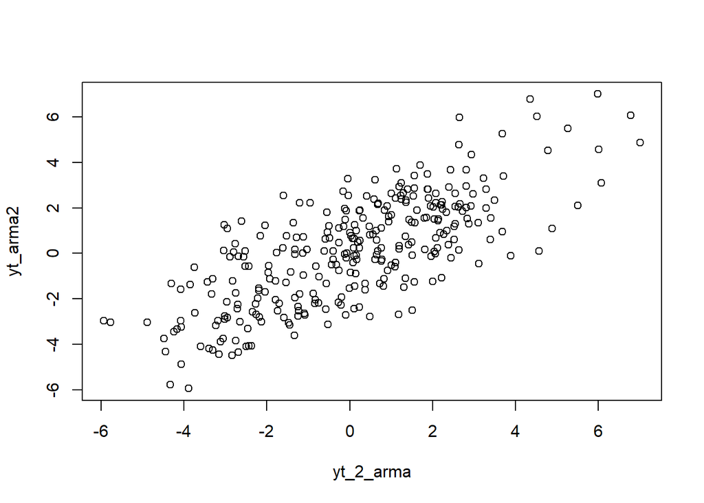

```r
plot(y=yt_arma2,x=yt_2_arma)
```

```r
cor(yt_arma2,yt_2_arma)
```

```
## [1] 0.7418336
```

#### Korelasi antara $Y_t$ dengan $Y_{t-3}$

```r
#Yt
yt_arma3 <- arma22[-c(1,2,3)]
yt_arma3
```

```
##   [1] -4.24238239 -3.32969759 -3.43621968 -1.78901941 -1.25132772 -1.20743150
##   [7] -2.34416668 -1.78461961 -2.55836435 -2.03719390 -0.14889635  1.22854017
##  [13]  1.19347310  2.54002752  0.32568943  1.29874673  1.55244715  2.65472724
##  [19]  3.40869679  2.18288992  1.56208081  0.91060560 -1.25132531 -0.75372897
##  [25] -2.75267062 -2.18656893 -3.84512294 -2.80420535 -1.36142264  0.06635720
##  [31]  1.34896589  0.64610343  0.75784633 -0.06632239 -0.32997595  0.00552452
##  [37] -0.49697221  0.90256206  1.19738237  2.08245409  2.93035227  2.64122266
##  [43]  4.34785519  5.97663019  6.77918615  7.00370536  6.07080428  4.87799480
##  [49]  3.10833325  1.09323104 -0.44207532 -0.59109348 -0.49001315  0.63577328
##  [55]  0.67572631  1.00359921  0.10132752 -0.52906110 -2.43039187 -3.11637910
##  [61] -4.05984851 -3.88585224 -4.88059362 -5.93680556 -3.02681564 -2.95115843
##  [67]  1.24516989  1.10316963  3.09650380  2.44070489  1.34952562 -0.20602668
##  [73] -1.09847618 -2.27237385 -2.64728518 -2.21643506 -3.01018840 -1.97131180
##  [79] -2.75580724 -0.84866299 -1.74383782 -2.19571982 -2.52034040 -1.61849899
##  [85]  0.10953163  0.23049227  0.64807339  0.23373869  0.58884022  1.86917559
```

[output cut: 35 more lines]

```r
#Yt-3
yt_3_arma <- arma22[-c(298,299,300)]
yt_3_arma
```

```
##   [1] -3.38970122 -3.30812898 -4.17033404 -4.24238239 -3.32969759 -3.43621968
##   [7] -1.78901941 -1.25132772 -1.20743150 -2.34416668 -1.78461961 -2.55836435
##  [13] -2.03719390 -0.14889635  1.22854017  1.19347310  2.54002752  0.32568943
##  [19]  1.29874673  1.55244715  2.65472724  3.40869679  2.18288992  1.56208081
##  [25]  0.91060560 -1.25132531 -0.75372897 -2.75267062 -2.18656893 -3.84512294
##  [31] -2.80420535 -1.36142264  0.06635720  1.34896589  0.64610343  0.75784633
##  [37] -0.06632239 -0.32997595  0.00552452 -0.49697221  0.90256206  1.19738237
##  [43]  2.08245409  2.93035227  2.64122266  4.34785519  5.97663019  6.77918615
##  [49]  7.00370536  6.07080428  4.87799480  3.10833325  1.09323104 -0.44207532
##  [55] -0.59109348 -0.49001315  0.63577328  0.67572631  1.00359921  0.10132752
##  [61] -0.52906110 -2.43039187 -3.11637910 -4.05984851 -3.88585224 -4.88059362
##  [67] -5.93680556 -3.02681564 -2.95115843  1.24516989  1.10316963  3.09650380
##  [73]  2.44070489  1.34952562 -0.20602668 -1.09847618 -2.27237385 -2.64728518
##  [79] -2.21643506 -3.01018840 -1.97131180 -2.75580724 -0.84866299 -1.74383782
##  [85] -2.19571982 -2.52034040 -1.61849899  0.10953163  0.23049227  0.64807339
```

[output cut: 35 more lines]

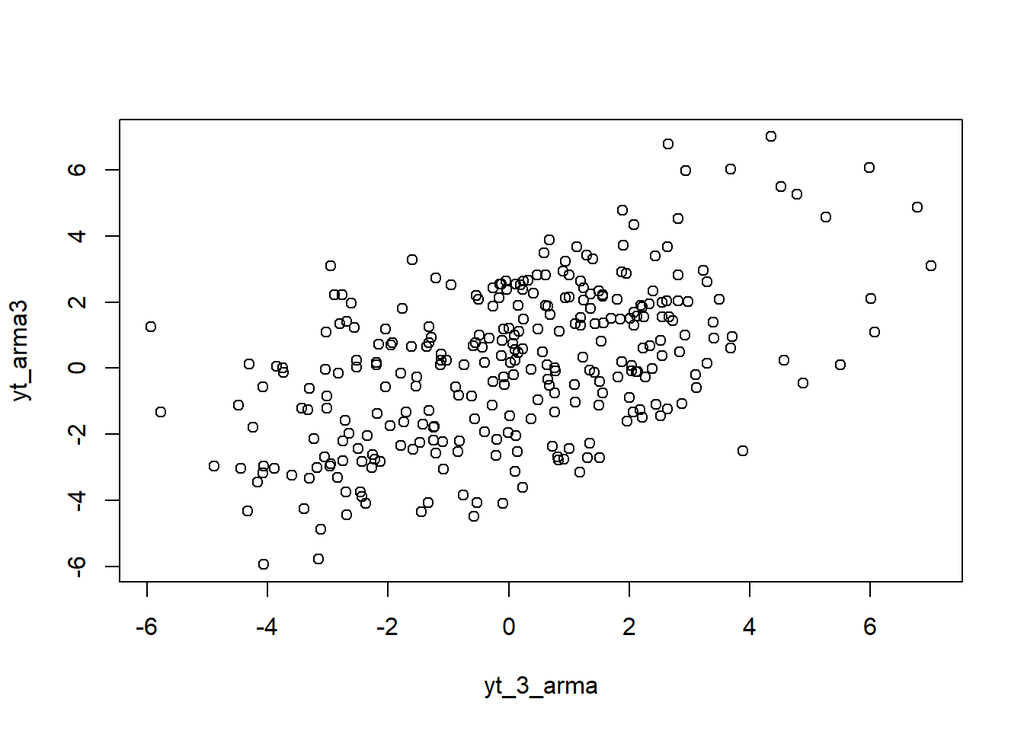

```r
plot(y=yt_arma3,x=yt_3_arma)
```

```r
cor(yt_arma3,yt_3_arma)
```

```
## [1] 0.5256935
```